# Exercise 1: Basic concepts on random variables and probability distributions

## Introduction

This notebook includes a series of cells with code (Python) and descriptive text (markdown) and provides a number of exercises. Work through the exercises and add, as appropriate, new cells with your code or descriptive text to answer the questions. All required data are provided in your exercise folder.

To submit your work, follow the steps '**Before you submit**' and '**How to submit**' in the *intro2notebook.ipynb* file contained in the *ex0_introduction_to_python.zip*. Please note that this is the same for all exercises.

### Part I: Basic statistics and probability calculation

```python
#First import some of the basic python packages we want to use:
import pandas as pd
import matplotlib.pyplot as plt
import numpy as np
%matplotlib inline
```

#### Question I.1

From monthly data (file *P_uppmonth1.dat*): compute for each month (column-wise) mean, median, mode, standard deviation, coefficient of variation, minimum and maximum. Plot these values (except the mode) to show the annual variation. Note that coefficient of variation has a different unit than the other statistics, and thus needs to be plotted in a separate figure.

```python
# Basic statistics can be easily calculated by defining DataFrames in pandas (like we did above)


# To add all of the values in a particular column of a DataFrame (or a Series), you can do the following:
#df[‘column_name’].sum()


# Note: Passing the argument of axis=0 returns the mean of every single column in the DataFrame; e.g. df.mean(axis=0)
#       Passing the argument of axis=1 returns the mean of every single  row   in the DataFrame; e.g. df.mean(axis=1)
```

```python
#Reading a .dat file
data = pd.read_table("P_uppmonth1.dat",index_col = 0, parse_dates = True)
data.head()
```

| year | Jan | Feb | Mar | Apr | May | Jun | Jul | Aug | Sep | Oct | Nov | Dec |
| --- | --- | --- | --- | --- | --- | --- | --- | --- | --- | --- | --- | --- |
| 1981-01-01 | 32 | 26 | 62 | 22 | 23 | 98 | 80 | 163 | 13 | 122 | 144 | 109 |
| 1982-01-01 | 42 | 30 | 54 | 50 | 192 | 37 | 52 | 77 | 48 | 46 | 74 | 52 |
| 1983-01-01 | 78 | 10 | 107 | 46 | 36 | 105 | 80 | 25 | 188 | 58 | 36 | 78 |
| 1984-01-01 | 72 | 29 | 34 | 11 | 29 | 97 | 67 | 51 | 145 | 114 | 51 | 51 |
| 1985-01-01 | 83 | 37 | 42 | 69 | 23 | 25 | 104 | 50 | 76 | 53 | 74 | 63 |

```python
#Making funktions so i can plot evrything
mean=data.mean()
median=data.median()
mode=data.mode()
std=data.std()
minimum=data.min()
maximum=data.max()
```

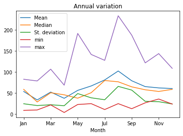

```python
#Plotting
mean.plot(label= "Mean")
median.plot(label="Median")
std.plot(label="St. deviation")
minimum.plot(label="min")
maximum.plot(label="max")
#mode.plot()

plt.legend()

plt.xlabel("Month")
plt.ylabel("")
plt.title("Annual variation");
```

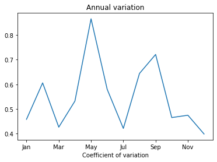

```python
#coefficient of variation
#coefficient of variation is the standard deviation devided by mean

cov= std/mean
cov.plot()
plt.xlabel("Coefficient of variation")
plt.ylabel("")
plt.title("Annual variation");
```

#### Question I.2

For daily data (file *P_Uppsala.dat*, values in [mm]): Estimate the probabilities that daily precipitation

1. equals zero
2. is more than zero
3. is more than 10 mm
4. is more than 10 mm on a day with precipitation

```python
#Reading data file
data2=pd.read_table("P_Uppsala.dat")
data2.set_index(['1981','1','1.1'])
data2.head()
```

|  | 1981 | 1 | 1.1 | 1.5 |
| --- | --- | --- | --- | --- |
| 0 | 1981 | 1 | 2 | 0.0 |
| 1 | 1981 | 1 | 3 | 0.0 |
| 2 | 1981 | 1 | 4 | 0.4 |
| 3 | 1981 | 1 | 5 | 0.0 |
| 4 | 1981 | 1 | 6 | 1.0 |

```python
#1.Probability of daily precipitation equals zero

#legth of dataset
length=data2.shape[0]
#data2.groupby().count()
data3=data2.apply(pd.value_counts)

zero=data3['1.5'][0]

probzero=zero/length

print('Probability of 0.0mm precipitation is',probzero)

#2.Probability of daily precipitation being mote than zero

probmz=1-probzero
print('Probability of precipitation is',probmz)

data3
```

```
Probability of 0.0mm precipitation is 0.5283864541832669
Probability of precipitation is 0.4716135458167331
```

|  | 1981 | 1 | 1.1 | 1.5 |
| --- | --- | --- | --- | --- |
| 0.0 | NaN | NaN | NaN | 2122.0 |
| 0.1 | NaN | NaN | NaN | 114.0 |
| 0.2 | NaN | NaN | NaN | 136.0 |
| 0.4 | NaN | NaN | NaN | 85.0 |
| 0.5 | NaN | NaN | NaN | 55.0 |
| ... | ... | ... | ... | ... |
| 1987.0 | 365.0 | NaN | NaN | NaN |
| 1988.0 | 366.0 | NaN | NaN | NaN |
| 1989.0 | 365.0 | NaN | NaN | NaN |
| 1990.0 | 365.0 | NaN | NaN | NaN |
| 1991.0 | 365.0 | NaN | NaN | NaN |

211 rows × 4 columns

```python
#3.Probability of daily precipitation is more than 10

ten=data2['1.5'][data2['1.5']>10].count()


prob10=ten/length
print('Probability of more than 10mm precipitation is',prob10)


#days with precipitation:
days=length-zero

prob10d=ten/days
print('Probability of more than 10mm on rainy days is', prob10d)
```

```
Probability of more than 10mm precipitation is 0.0575199203187251
Probability of more than 10mm on rainy days is 0.12196409714889124
```